# Devloping Data Products

9/7/2020

## Objectives of Assignment

This is a task for the data science coursera course about developing data products for week 4. As part of this, I have created a shiny app and deployed it on the shiny server. The link for raw code is https://github.com/im-utkarsh/Devloping-Data-Products-Shiny/tree/master/Devloping-Data-Product.

The app can be found at https://im-utkarsh.shinyapps.io/devloping-data-product/.

## Data

The data used is the *states* data which is available in R by default.

Note : Only `state.x77` data is used in this assignment.

Matrix with 50 rows and 8 columns give the following statistics in the respective columns :

- Population: population estimate as of July 1, 1975
- Income: per capita income (1974)
- Illiteracy: illiteracy (1970, percent of population)
- Life Exp: life expectancy in years (1969–71)
- Murder: murder and non-negligent manslaughter rate per 100,000 population (1976)
- HS Grad: percent high-school graduates (1970)
- Frost: mean number of days with minimum temperature below freezing (1931–1960) in capital or large city
- Area: land area in square miles

### Source

- U.S. Department of Commerce, Bureau of the Census (1977) Statistical Abstract of the United States.
- U.S. Department of Commerce, Bureau of the Census (1977) County and City Data Book.

## Overview

The shiny app plots graph against *Income* for different variables from the `states.x77` dataset.

```r
data <- data.frame(state.x77)
head(data)
```

```
           Population Income Illiteracy Life.Exp Murder HS.Grad Frost   Area
Alabama          3615   3624        2.1    69.05   15.1    41.3    20  50708
Alaska            365   6315        1.5    69.31   11.3    66.7   152 566432
Arizona          2212   4530        1.8    70.55    7.8    58.1    15 113417
Arkansas         2110   3378        1.9    70.66   10.1    39.9    65  51945
California      21198   5114        1.1    71.71   10.3    62.6    20 156361
Colorado         2541   4884        0.7    72.06    6.8    63.9   166 103766
```

## Plots

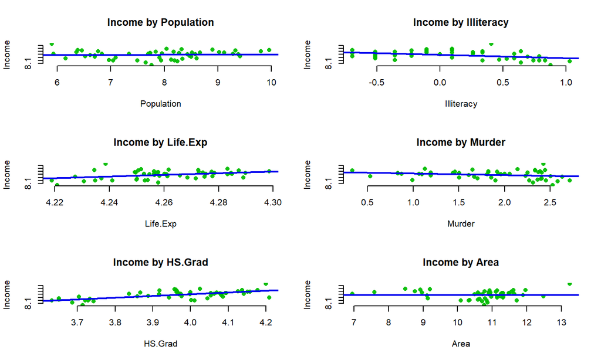

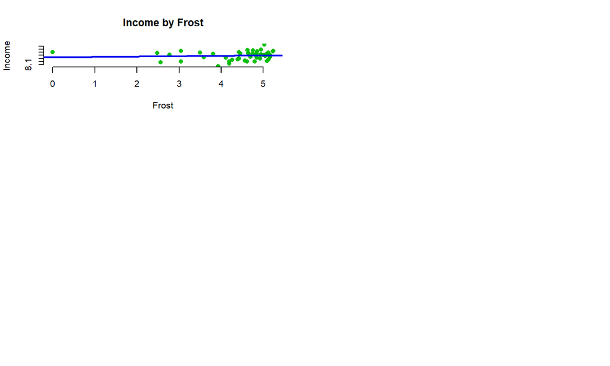